# Happiness from Teen Years through Middle-Age

Rishabh Ganesh

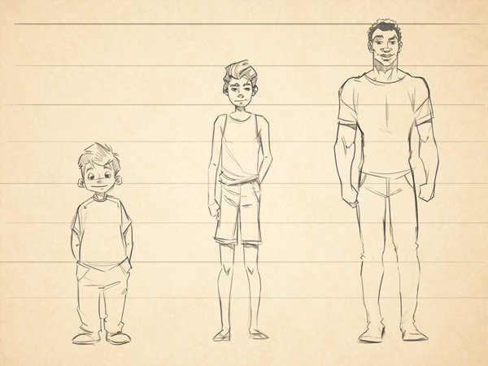

### Question 1 - What do teenagers most associate their happy moments with?

There are 100,392 happy moments reported, and teenagers reported 1465 moments. Since this is roughly 1% of all the moments reported, teenagers comprise a tiny portion of the participants.

```r
#print the number of happy moments for those under 20
under20 <- joined_df %>%
  dplyr::filter(age < 20 & age >= 18)
num_under20 = nrow(under20)
print(num_under20)
```

```
## [1] 1465
```

The moments described are grouped into categories based on their content, and teenagers most frequently experience happy moments in the context of achievement. A significant amount of their happy moments are also related to affection and simply enjoying the moment.

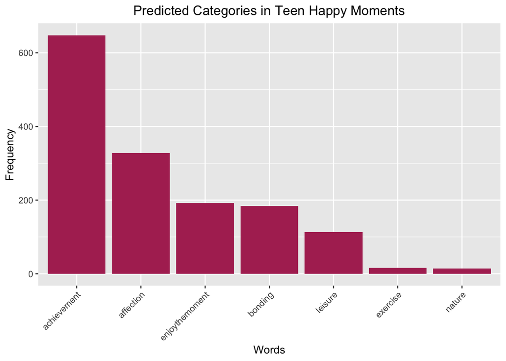

```r
#visualize prevalent categories for teens
ggplot(maindata, aes(x = reorder(word,-freq), y = freq)) +
  geom_bar(stat = "identity", fill = "maroon") +
  labs(title = "Predicted Categories in Teen Happy Moments", x = "Words", y = "Frequency") +
  theme(axis.text.x = element_text(angle = 45, hjust = 1))  + theme(plot.title=element_text(hjust=0.5))
```

When looking further into the their happy moments, we can go beyond grouping teenage happy moments into general predicted categories, and find the specific words that teenagers are thinking about. Notice how teenagers find happiness in contexts like academics, interpersonal relationships, and career, consistent with the predicted categories of achievement, affection, and enjoying the moment. The word cloud below sheds light on the words that describe the topics teenagers think about. Latent Dirichlet Allocation is the topic modeling technique used to find these words.

```r
#visualize topics from LDA as a wordcloud
ya_corpus <- tm_filter(ya_corpus, function(x) length(unlist(strsplit(as.character(x), " "))) > 0)
doctermatrix <- DocumentTermMatrix(ya_corpus)
topic_model <- LDA(doctermatrix, k= num_topics)
#terms(topic_model, 20)
terms_vector <- terms(topic_model)[1:20]
word_freq_df <- data.frame(word = terms_vector, freq = 1)
wordcloud2(word_freq_df, size=0.5, rotateRatio= 0)
```

[interactive chart not shown]

### Question 2 - What are teenagers feeling during their happy moments?

The sentiments that teenagers express during their happy moments go a long way in revealing what they feel during their happy moments. Using the [AFINN](http://corpustext.com/reference/sentiment_afinn.html) lexicon, a list of terms rated between -5 and 5 to determine how strong of a positive or negative sentiment a word expresses, we can look at what teenagers are saying and how they feel while expressing their happy moments. Teenagers who use express the sentiment “outstanding” during their happy moments notably experienced a positive feeling.

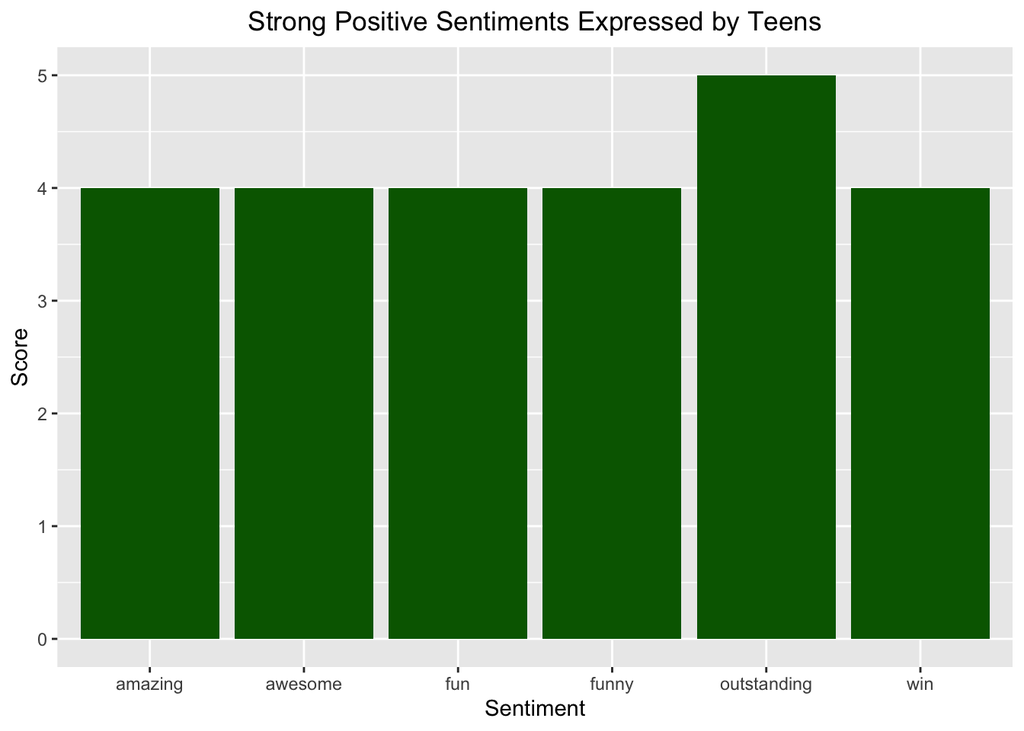

```r
#visualize positive sentiments of teenagers
ggplot(head(sorted_sents, 20), aes(x = word, y = sentiment, fill = factor(sign(sentiment)))) +
  geom_bar(stat = "identity", position = "identity") +
  scale_fill_manual(values = "darkgreen", guide = "none") +
  labs(title = "Strong Positive Sentiments Expressed by Teens", x = "Sentiment", y = "Score")  + theme(plot.title=element_text(hjust=0.5))
```

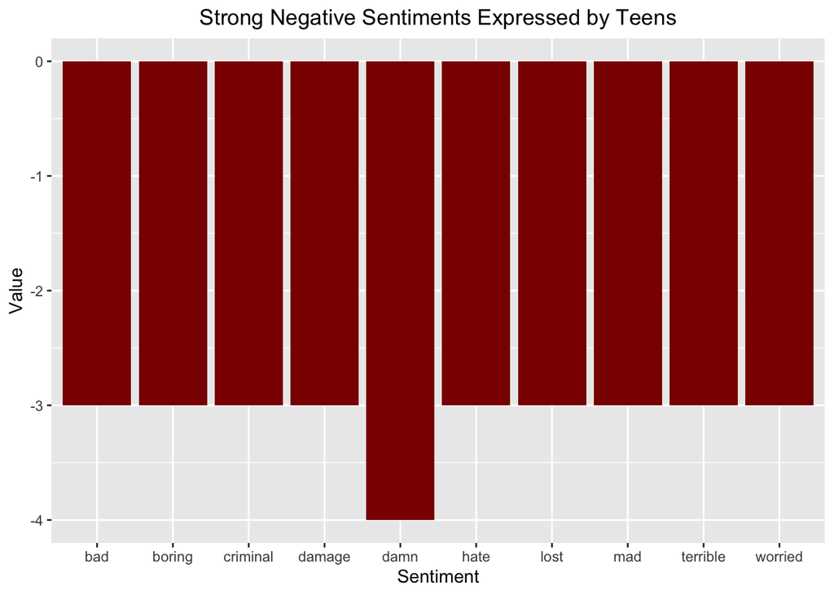

```r
#visualize negative sentiments of teens
sorted_badsents <- word_sentiments[order(word_sentiments$sentiment), ]
ggplot(head(sorted_badsents, 20), aes(x = word, y = sentiment, fill = factor(sign(sentiment)))) +
  geom_bar(stat = "identity", position = "identity") +
  scale_fill_manual(values = "darkred", guide = FALSE) +
  labs(title = "Strong Negative Sentiments Expressed by Teens", x = "Sentiment", y = "Value")  + theme(plot.title=element_text(hjust=0.5))
```

The negative sentiments may come as a surprise, but some teenagers may convey a happy moment by framing it in a way that entails avoiding an unhappy situation.

The words that teenagers are saying most frequently in their happy moments can add a layer of depth and context to the sentiments they express. The most frequent word by far is “friend,” which makes sense because teenagers who report a happy moment are likely to recall enjoyable experiences with friends. Note, however, that the word “friend” may not be what comes to mind when thinking of the major predicted categories of teenage happy moments, like achievement and affection. Perhaps teenagers associate achievement with having many friends. Teenagers also attend events and use words like “game” and “played,” which means they experience some happiness from engaging with others.

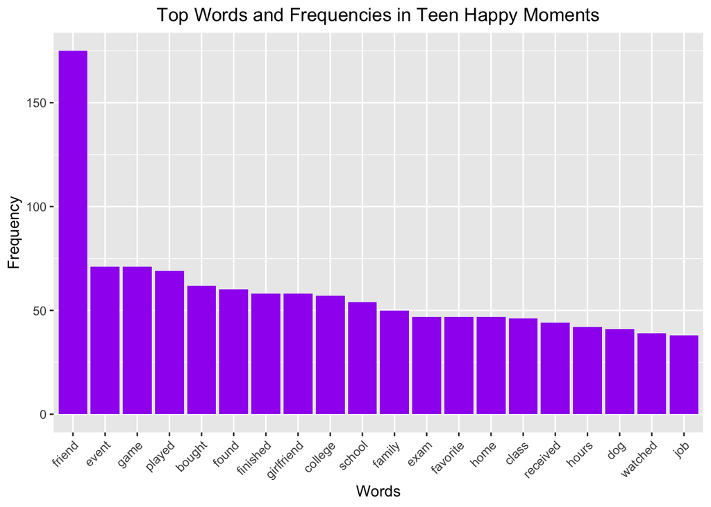

```r
#visualize frequent words for teens
ggplot(maindata, aes(x = reorder(word,-freq), y = freq)) +
  geom_bar(stat = "identity", fill = "purple") +
  labs(title = "Top Words and Frequencies in Teen Happy Moments", x = "Words", y = "Frequency") +
  theme(axis.text.x = element_text(angle = 45, hjust = 1))  + theme(plot.title=element_text(hjust=0.5))
```

The word association plot below can reveal more about how teenagers think about things and relate them in their happy moments.

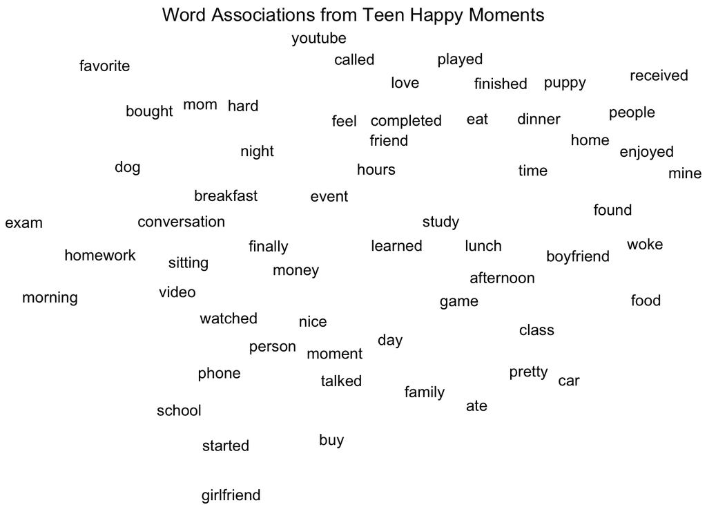

```r
#plot word associations for teens
ggplot(df, aes(x = x, y = y, label = word)) +
  geom_text_repel(max.overlaps = 500) + theme_void() +
  labs(title = "Word Associations from Teen Happy Moments")  + theme(plot.title=element_text(hjust=0.5))
```

### Question 3 - What do middle-aged adults who relate happiness to achievement experience during their happy moments?

I define middle-aged adult as someone aged between 30 and 49 inclusive, which is almost the entirety of the second quarter of their life. I choose this age range because those in their twenties are often considered to be young adults, or even sometimes accused of faking their way into adulthood. Once a person reaches middle age, the assumption is that they know themselves better than they had in any previous age bracket, so they can be seen as more certain about what makes them happy in their happy moments. Since achievements is the most common predicted category of teen happy moments, I focus on the middle-aged adults whose happy moments also have achievements as their predicted category. Achievements is also the among the most common predicted category for adults. These are the adults whom the teenagers whose happy moments are based on achievement are likely to grow to become.

```r
#print number of happy moments for middle aged adults focused on achievements
print(nrow(mid_df))
```

```
## [1] 44736
```

In the many happy moments that achievement-focused middle-aged adults experience, below are the words they think about most frequently. Naturally, they tend to be career focused.

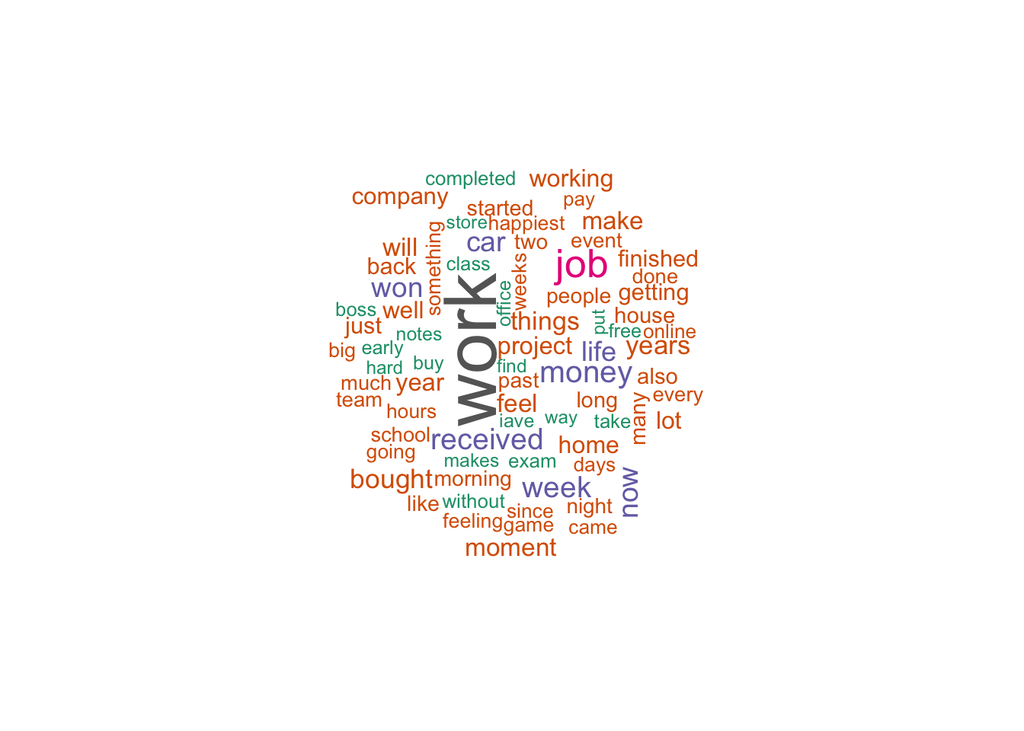

```r
wordcloud(words = worddata$word, freq = worddata$freq, scale = c(3, 0.5), colors = brewer.pal(8, "Dark2"))
```

As such, the words they most frequently use in their happy moments are related to work, jobs, and money.

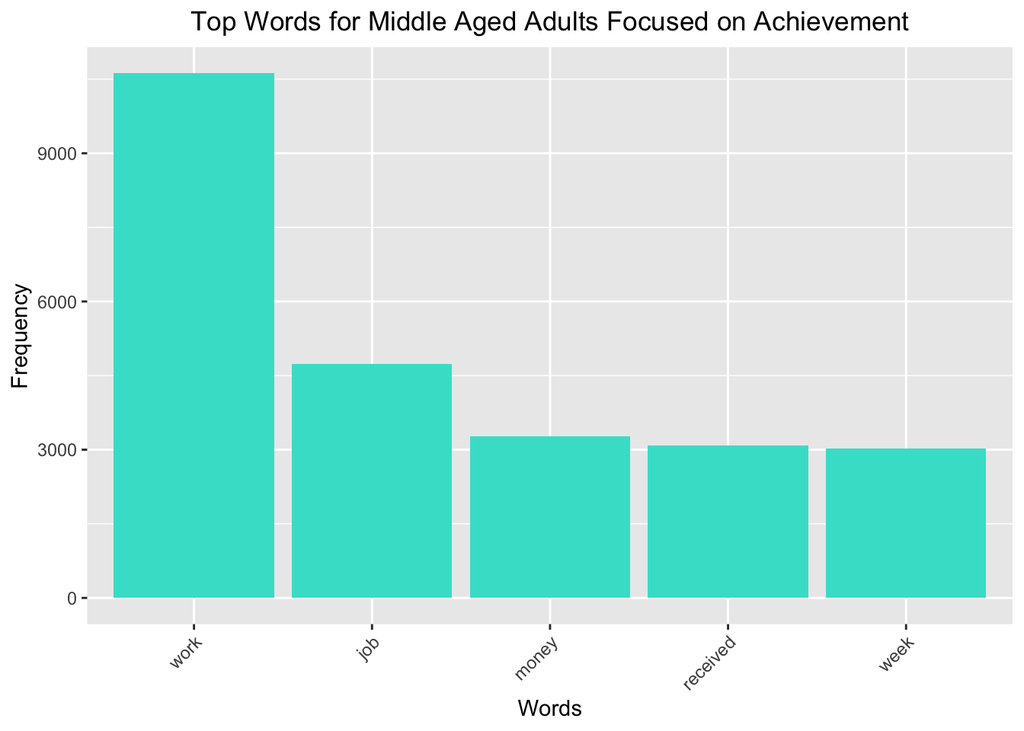

```r
#visualize top words
ggplot(top5data, aes(x = word, y = freq)) +
  geom_bar(stat = "identity", fill = "turquoise") +
  labs(title = "Top Words for Middle Aged Adults Focused on Achievement", x = "Words", y = "Frequency") +
  theme(axis.text.x = element_text(angle = 45, hjust = 1))  + theme(plot.title=element_text(hjust=0.5))
```

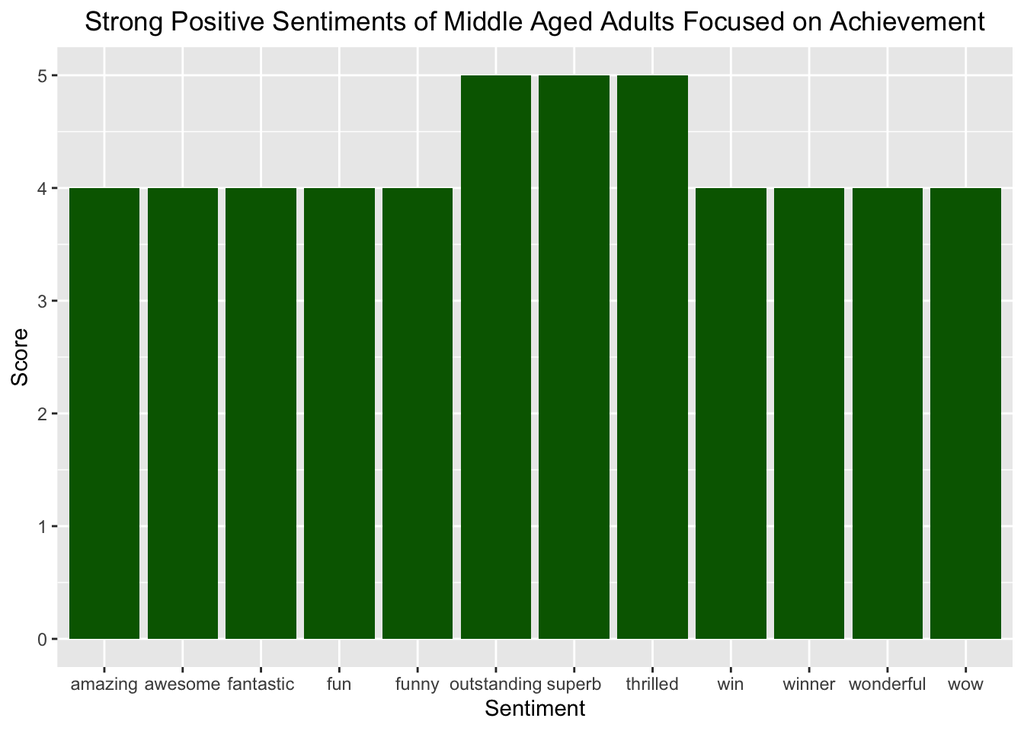

```r
#visualize positive sentiments for middle aged adults
ggplot(head(sorted_sents, 600), aes(x = word, y = sentiment, fill = factor(sign(sentiment)))) +
  geom_bar(stat = "identity", position = "identity") +
  scale_fill_manual(values = "darkgreen", guide = "none") +
  labs(title = "Strong Positive Sentiments of Middle Aged Adults Focused on Achievement", x = "Sentiment", y = "Score")  + theme(plot.title=element_text(hjust=0.5))
```

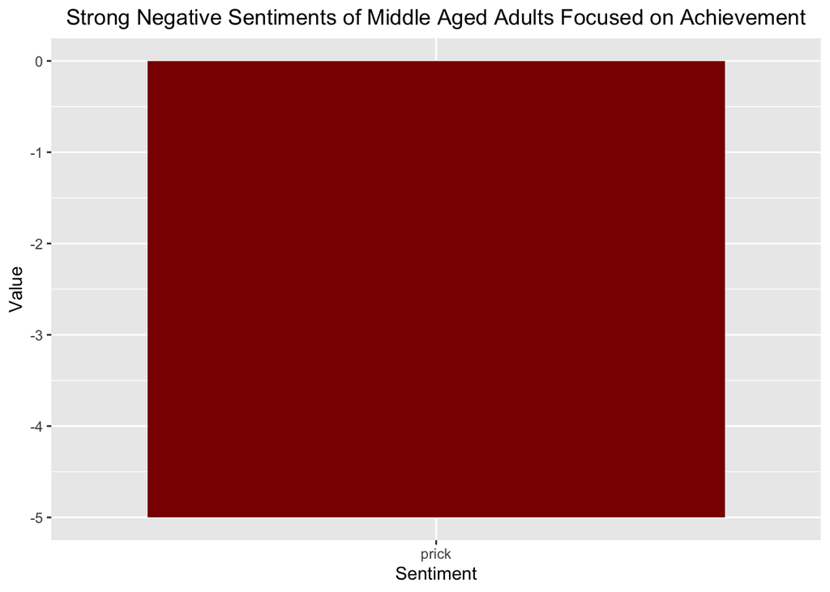

```r
#visualize negative sentiments for middle aged adults
sorted_badsents <- word_sentiments[order(word_sentiments$sentiment), ]
ggplot(head(sorted_badsents, 1), aes(x = word, y = sentiment, fill = factor(sign(sentiment)))) +
  geom_bar(stat = "identity", position = "identity") +
  scale_fill_manual(values = "darkred", guide = FALSE) +
  labs(title = "Strong Negative Sentiments of Middle Aged Adults Focused on Achievement", x = "Sentiment", y = "Value")  + theme(plot.title=element_text(hjust=0.5))
```

The word association plot below shows how achievement-focused middle aged adults associate the words they use in their happy moments. The clusters are more well defined than the clusters in the word association plot for teenage happy moments presumably because the words are taken from happy moments that share the same predicted category.

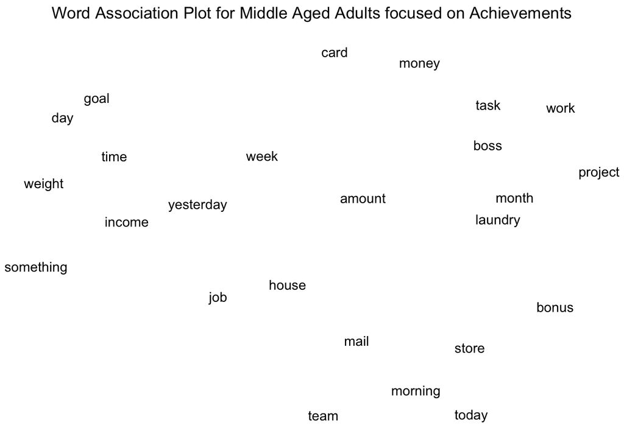

```r
#plot word association
ggplot(df, aes(x = x, y = y, label = word)) +
  geom_text_repel(max.overlaps = 500) + theme_void() +
  labs(title = "Word Association Plot for Middle Aged Adults focused on Achievements") + theme(plot.title=element_text(hjust=0.5))
```

Looking more holistically at middle-aged adults, below is the frequency of each predicted category for adults. The main distinction between adults and teenagers in terms of predicted categories is that affection is the most common predicted category for adults, as opposed to achievement for teens. In addition, the most frequent predicted category for teens is significantly more frequent than the second most frequent predicted category, whereas for adults, the first and second most frequent predicted category in their happy moments are close.

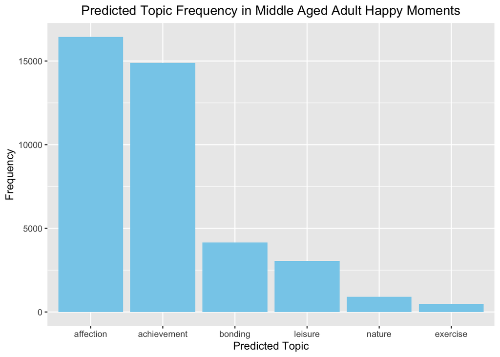

```r
#plot predicted topic frequencies for middle aged adults
ggplot(data, aes(x = reorder(categories,-category_sizes), y = category_sizes)) +
  labs(title = "Predicted Topic Frequency in Middle Aged Adult Happy Moments", x = "Predicted Topic", y = "Frequency") + theme(plot.title=element_text(hjust=0.5)) +
  geom_bar(stat = "identity", fill = "skyblue")
```

## Conclusions

1. Happiness is relative and context-dependent. As a teenager, achieving good grades may be the greatest source of happiness. As a middle-aged adult, earning a promotion may be the greatest source of happiness. *Both of these are the same.* The adult earning a promotion is not necessarily more or less happy than the teenager who is achieving good grades. In their respective contexts, the strong positive sentiments show that they are both feeling happy, and that is what matters most.
2. When conveying happy moments, people will express negative sentiments. These sentiments can be surprisingly strong. Many reported happy moments show that people experience happy moments when sources of unhappiness are removed.
3. The most significant difference between adults and teenagers is the most frequent category which their respective happy moments fall under. Teenagers are generally focused on achievements when reporting happy moments, whereas adults show significant consideration for affection in addition to achievement.